# Python入門 - Sekikawa

- Pythonの基本的な文法
- pandas
- scikit-learn

[figure not shown]

## 目次

### 1. Pythonの特徴

```
- 言語の特徴
- 強みと弱み
```

### 2. Pythonの基本的な文法

```
- 基本演算
- if文
- for文
- 関数
```

### 3. pandas入門

```
- 基本事項
- よく使うクラス・メソッド紹介
```

### 4. sklearn入門

```
- 基本事項
- よく使うクラス・メソッド紹介
```

## 1. Pythonの特徴

### 1.1. 言語の特徴

- 1991年生まれのインタプリタ系のプログラミング言語
- コードの可読性を重視して作られている

#### 自分の持つPythonのイメージ

- スマート側の言語 (お堅い側ではない)
- 堅牢なシステムには向かないイメージ
- 合理的かつ読みやすいコードが簡単に作れる
- データ分析

```python
# Pythonプログラマが持つべき心構え
# import this
```

### [The Zen of Python(Pythonの哲学)](https://qiita.com/IshitaTakeshi/items/e4145921c8dbf7ba57ef)

**Beautiful is better than ugly.**  
**醜いより美しいほうがいい。**

Explicit is better than implicit.  
暗示するより明示するほうがいい。

**Simple is better than complex.**  
**複雑であるよりは平易であるほうがいい。**

Complex is better than complicated.  
それでも、込み入っているよりは複雑であるほうがまし。

Flat is better than nested.  
ネストは浅いほうがいい。

Sparse is better than dense.  
密集しているよりは隙間があるほうがいい。

**Readability counts.**  
**読みやすいことは善である。**

Special cases aren't special enough to break the rules.  
特殊であることはルールを破る理由にならない。

Although practicality beats purity.  
しかし、実用性を求めると純粋さが失われることがある。

Errors should never pass silently.  
エラーは隠すな、無視するな。

Unless explicitly silenced.  
ただし、わざと隠されているのなら見逃せ。

**In the face of ambiguity, refuse the temptation to guess.**  
**曖昧なものに出逢ったら、その意味を適当に推測してはいけない。**

**There should be one-- and preferably only one --obvious way to do it.**  
**何かいいやり方があるはずだ。誰が見ても明らかな、たったひとつのやり方が。**

Although that way may not be obvious at first unless you're Dutch.  
そのやり方は一目見ただけではわかりにくいかもしれない。オランダ人にだけわかりやすいなんてこともあるかもしれない。

Now is better than never.  
ずっとやらないでいるよりは、今やれ。

Although never is often better than *right* now.  
でも、今"すぐ"にやるよりはやらないほうがマシなことが多い。

**If the implementation is hard to explain, it's a bad idea.**  
**コードの内容を説明するのが難しいのなら、それは悪い実装である。**

**If the implementation is easy to explain, it may be a good idea.**  
**コードの内容を容易に説明できるのなら、おそらくそれはよい実装である。**

Namespaces are one honking great idea -- let's do more of those!  
名前空間は優れたアイデアであるため、積極的に利用すべきである。

### 1.2. Pythonの強み

#### 1. 少ないコードで簡潔にプログラムが書ける

```
- 誰が書いても同じコードとなるように配慮されている
- やりたいことを直感的に記載すると良い感じにやってくれる
    - 上記は場合によって意図しないバグを生むので注意
```

#### 2. コミュニティが活発

```
- 習得したいプログラミング言語1位
- データ分析はPythonがグローバルスタンダード
- 「やりたいこと Python」で検索すると大体ヒットする
```

#### 3. ライブラリが充実している

```
- データ分析, RPA, AWS, Webアプリ, サーバなど
- GitHubで探せば大体何でもある
```

### 1.2. Pythonの弱み

#### 1. 実行が遅い

```
- CとかC++より遅いのはもちろん，Javaとか他のコンパイラ系の言語にほとんどの場合で負ける
- 工夫のしようはある (PyPy, Cython, ライブラリ)
```

#### 2. 身に覚えのないエラーに遭遇しがち

```
- 明示しなくとも良い感じにやってくれるが故のもの
```

#### 3. Python以外のプログラミングがしんどくなる

```
- Pythonに慣れると他の言語のコーディングが面倒になる
    - Pythonなら簡単にできることが他の言語では簡単にできない
    - Pythonならxxxで一行で出来るのに，何行もかけて実装しないといけないのか...
    - ライブラリないから全部コード組まないといけないのか...
    - ググっても分かりやすくまとめてくれている記事ないなあ．．．
```

## 2. Pythonの基本的な文法

クラスなどの面倒なところは全て飛ばして，今回の研修で使う内容に絞って扱います．

### 2.1. 基本演算

- 直感的に書けば問題なし
- 演算でよく使う記号：+, -, *, /, %(余り)
- Pythonは動的型付けなので，型の宣言は不要

```python
# シャープ付けるとコメントアウトになる
# 四則演算
print("1 + 2 * 3 / 4 = ", 1 + 2 * 3 / 4)

a = 1
b = 2
c = 3
d = 4
result = a + b * c / d
print("a + b * c / d = ", result)
```

```
1 + 2 * 3 / 4 =  2.5
a + b * c / d =  2.5
```

### 2.2. if文

- if, elif, elseという予約語を使う
- 言葉で説明するよりも，例で見た方が早い
- 条件式では，イコール(**==**), ノットイコール(**!=**), 不等号(**>, <, <=, >=**)を使用する場合が多い

```
# if else
if 条件式:
    条件式がTrueの時の処理文
else:
    条件式がFalseの時の処理文
```

```
# if elif else
if 条件式1:
    条件式1がTrueの時の処理文
elif 条件式2:
    条件式1がFalse，かつ，条件式2がTrueの時の処理文
else:
    条件式1と条件式2がどちらもFalseの時の処理文
```

```python
a = 2021

if (a == 2021): # かっこはつけてもつけなくても良い
    print("a == 2021")
else:
    print("a != 2021")
```

```
a == 2021
```

```python
a = 2021

if a % 2 == 0:
    print("aは偶数")

elif a % 3 == 0:
    print("aは3の倍数")

else:
    print("aは2でも3でも割れません")
```

```
aは2でも3でも割れません
```

### 2.2. for文

- 言葉で説明するよりも，例で見た方が早い

```
# for
for item in イテラルオブジェクト:
    処理文
```

イテラルオブジェクトは，データを一つずつ渡していってくれるオブジェクトのこと  
(Pythonだと，__getitem__(self, index)という関数を持つオブジェクトのこと)

```python
# 配列はイテラルオブジェクト
# 配列は，[]の中にカンマ区切りでデータを記述する
l = [0,1,2,3,4]

for i in l:
    print(i)
print()
```

```
0
1
2
3
4
```

```python
# Pythonでは文字列もイテラルオブジェクト
s = "string"

for char in s:
    print(char)
```

```
s
t
r
i
n
g
```

### 2.2. 関数

- 言葉で説明するよりも，例で見た方が早い

```
# func
def 関数名(引数1, 引数2, ．．．):
    処理文
    return 返り値
```

```python
# 返り値はなしでもOK
def func1(iterable_object):
    for i in iterable_object:
        print(i)

func1(s)
```

```
s
t
r
i
n
g
```

```python
def func2(a, b, c, d):
    return a + b * c / d

r = func2(1, 2, 3, 4)
print(r)
```

```
2.5
```

```python
# デフォルト引数を指定できる
def func3(a=1, b=2, c=3, d=4):
    return a + b * c / d

r = func3()
print("func2() = ", r)

r = func3(2,3,4,5)
print("func2(2,3,4,5) = ", r)
```

```
func2() =  2.5
func2(2,3,4,5) =  4.4
```

## 3. pandas入門

[figure not shown]

### 3.1. pandasとは

- データ分析で使用するライブラリ
- 表形式のデータをPython上で扱う際に使用するもの
  - 基本的にpandas.DataFrame型というものを使用する
- csvファイルを読み取って使う場合が多い

```python
# pandasのインポート
import pandas as pd

# numpyのインポート(あまり意識しなくて大丈夫です)
import numpy as np

# 辞書型 javaのmap型(あまり意識しなくて大丈夫です)
d = {
    "column1": [1,2,3,4],
    "column2": ["a", "b", "c", "d"],
    "column3": [0.1, 0.2, 0.3, 0.4],
    "column4": [1, np.nan, np.nan, 4],
}

# データフレーム型で変数を作成
df = pd.DataFrame(d)
df.head()
```

|  | column1 | column2 | column3 | column4 |
| --- | --- | --- | --- | --- |
| 0 | 1 | a | 0.1 | 1.0 |
| 1 | 2 | b | 0.2 | NaN |
| 2 | 3 | c | 0.3 | NaN |
| 3 | 4 | d | 0.4 | 4.0 |

### 3.2. よく使う操作

pandasの機能について詳しく触れていると，それだけで1日かかるのでよく使う機能に絞って紹介する

### 3.2.1. 指定した列のデータを取得する

#### 1列取ってくる場合

- df["カラム名"]
- df.カラム名

#### 複数列取ってくる場合

- df[["カラム名1", "カラム名2"]]

```python
# column1のみ取り出す
display(df["column1"])

print()

display(df.column1)
```

```
0    1
1    2
2    3
3    4
Name: column1, dtype: int64
```

```
0    1
1    2
2    3
3    4
Name: column1, dtype: int64
```

```python
# 複数列の場合は，配列で指定する
col = ["column1", "column2"]
display(df[col])
```

|  | column1 | column2 |
| --- | --- | --- |
| 0 | 1 | a |
| 1 | 2 | b |
| 2 | 3 | c |
| 3 | 4 | d |

### 3.2.2. 指定した行のデータを取得する

#### 1行取ってくる場合

- df.loc[インデックス番号]

#### 複数行とってくる場合

```python
display(df.loc[2])
```

```
column1      3
column2      c
column3    0.3
column4    NaN
Name: 2, dtype: object
```

```python
display(df.loc[2:3])
```

|  | column1 | column2 | column3 | column4 |
| --- | --- | --- | --- | --- |
| 2 | 3 | c | 0.3 | NaN |
| 3 | 4 | d | 0.4 | 4.0 |

### 3.2.3. 列の削除

- df.drop("カラム名", axis=1)

```python
temp = df.drop("column1", axis=1)
display(temp)
```

[output not shown]

### 3.2.4. 行の削除

- df.drop("インデックス番号")

```python
temp = df.drop(1)
display(temp)
```

[output not shown]

### 3.2.5. naが含まれる列の判定

- df.isna().sum()

```python
df.isna().sum()
```

```
column1    0
column2    0
column3    0
column4    2
dtype: int64
```

- df.dropna()

```python
temp = df.dropna()
display(temp)
```

|  | column1 | column2 | column3 | column4 |
| --- | --- | --- | --- | --- |
| 0 | 1 | a | 0.1 | 1.0 |
| 3 | 4 | d | 0.4 | 4.0 |

### 3.2.7. 統計情報の出力

- df.describe()
- df.describe(include="all")

```python
df.describe()
```

|  | column1 | column3 | column4 |
| --- | --- | --- | --- |
| count | 4.000000 | 4.000000 | 2.00000 |
| mean | 2.500000 | 0.250000 | 2.50000 |
| std | 1.290994 | 0.129099 | 2.12132 |
| min | 1.000000 | 0.100000 | 1.00000 |
| 25% | 1.750000 | 0.175000 | 1.75000 |
| 50% | 2.500000 | 0.250000 | 2.50000 |
| 75% | 3.250000 | 0.325000 | 3.25000 |
| max | 4.000000 | 0.400000 | 4.00000 |

### 3.2.8. 新たな列の追加

- df["新しいカラム名"] = 初期値

```python
df["new_column"] = "new"
display(df)
```

|  | column1 | column2 | column3 | column4 | new_column |
| --- | --- | --- | --- | --- | --- |
| 0 | 1 | a | 0.1 | 1.0 | new |
| 1 | 2 | b | 0.2 | NaN | new |
| 2 | 3 | c | 0.3 | NaN | new |
| 3 | 4 | d | 0.4 | 4.0 | new |

```python
# 列の値の上書き
df["new_column"] = df["column1"] + df["column3"]
display(df)
```

|  | column1 | column2 | column3 | column4 | new_column |
| --- | --- | --- | --- | --- | --- |
| 0 | 1 | a | 0.1 | 1.0 | 1.1 |
| 1 | 2 | b | 0.2 | NaN | 2.2 |
| 2 | 3 | c | 0.3 | NaN | 3.3 |
| 3 | 4 | d | 0.4 | 4.0 | 4.4 |

### pandasの参考

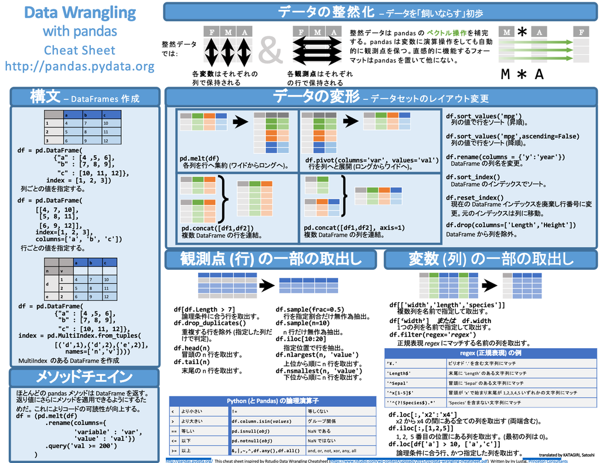

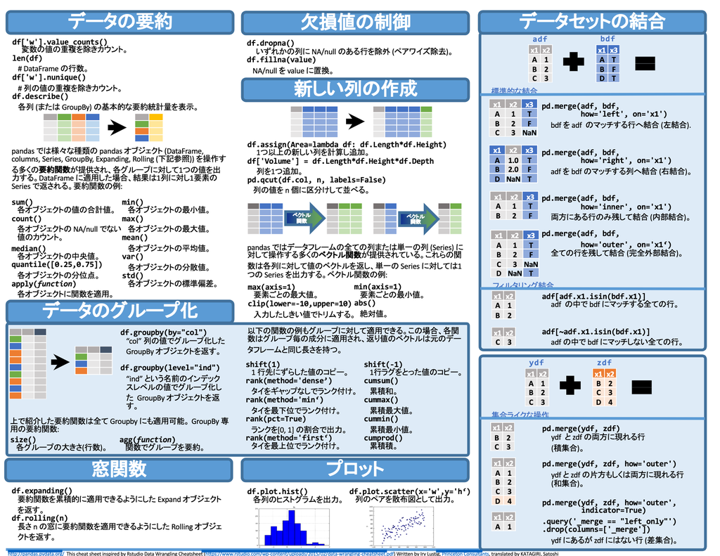

## 4. scikit-learn入門

[figure not shown]

### 4.1. scikit-learnとは

- 機械学習モデルや機械学習に関連する様々な機能を提供してくれるライブラリ
  - 各種機械学習モデル, データの切り分け, metricの計算など

### 4.2. よく使う機能

pandas同様，よく使う機能に絞って紹介する

```python
# サンプルデータの生成
from sklearn.datasets import make_regression

X, y, coef = make_regression(
    random_state=42,
    n_samples=100,
    n_features=10,
    n_informative=2,
    noise=1,
    bias=-0.0,
    coef=True
)

X = pd.DataFrame(X, columns=["column" + str(i) for i in range(1, 11)])
y = pd.DataFrame(y, columns=["target"])
```

```python
# 説明変数のつもり
X.head()
```

|  | column1 | column2 | column3 | column4 | column5 | column6 | column7 | column8 | column9 | column10 |
| --- | --- | --- | --- | --- | --- | --- | --- | --- | --- | --- |
| 0 | -2.123896 | 0.341756 | -0.576904 | -0.839722 | -0.525755 | 0.150394 | -0.599393 | 0.950424 | 1.876171 | -0.759133 |
| 1 | 0.871125 | -2.038125 | -0.351513 | 0.289775 | -0.326024 | -0.408075 | 2.075401 | -1.870792 | -1.008086 | 1.201214 |
| 2 | 0.244967 | -1.448084 | -0.213447 | -0.822220 | -0.506943 | 0.232050 | 0.243687 | -0.718444 | -1.407464 | -0.471038 |
| 3 | 0.478980 | -0.269875 | 0.377300 | 0.071566 | 0.333662 | -0.510016 | -0.477657 | -0.444293 | -0.978764 | 1.037540 |
| 4 | -0.624819 | 0.186767 | -1.406661 | -1.840874 | 0.026091 | -0.725744 | -1.279577 | -0.611518 | -0.755383 | 0.517659 |

```python
X.describe()
```

|  | column1 | column2 | column3 | column4 | column5 | column6 | column7 | column8 | column9 | column10 |
| --- | --- | --- | --- | --- | --- | --- | --- | --- | --- | --- |
| count | 100.000000 | 100.000000 | 100.000000 | 100.000000 | 100.000000 | 100.000000 | 100.000000 | 100.000000 | 100.000000 | 100.000000 |
| mean | -0.048511 | -0.047772 | 0.058295 | 0.003618 | 0.108974 | -0.032549 | 0.002578 | 0.031172 | 0.038018 | 0.079499 |
| std | 1.026363 | 0.954652 | 1.022648 | 0.894297 | 1.016550 | 0.976823 | 1.047359 | 0.921830 | 0.904248 | 1.042712 |
| min | -3.241267 | -2.696887 | -1.987569 | -1.918771 | -2.198806 | -2.211135 | -2.301921 | -2.650970 | -2.423879 | -2.619745 |
| 25% | -0.700307 | -0.776155 | -0.628305 | -0.574156 | -0.678367 | -0.705970 | -0.710363 | -0.532816 | -0.572616 | -0.622252 |
| 50% | -0.023125 | 0.013466 | -0.014331 | 0.079078 | 0.200009 | -0.063027 | -0.052911 | 0.064005 | 0.094496 | -0.027014 |
| 75% | 0.636509 | 0.530416 | 0.697232 | 0.532233 | 0.853640 | 0.637617 | 0.804413 | 0.552765 | 0.601449 | 0.815031 |
| max | 2.560085 | 1.886186 | 3.852731 | 2.526932 | 2.463242 | 2.632382 | 2.075401 | 3.078881 | 2.455300 | 2.573360 |

```python
# 目的変数のつもり
y.head()
```

|  | target |
| --- | --- |
| 0 | -20.107146 |
| 1 | 26.529688 |
| 2 | -11.705761 |
| 3 | -4.166765 |
| 4 | -43.215430 |

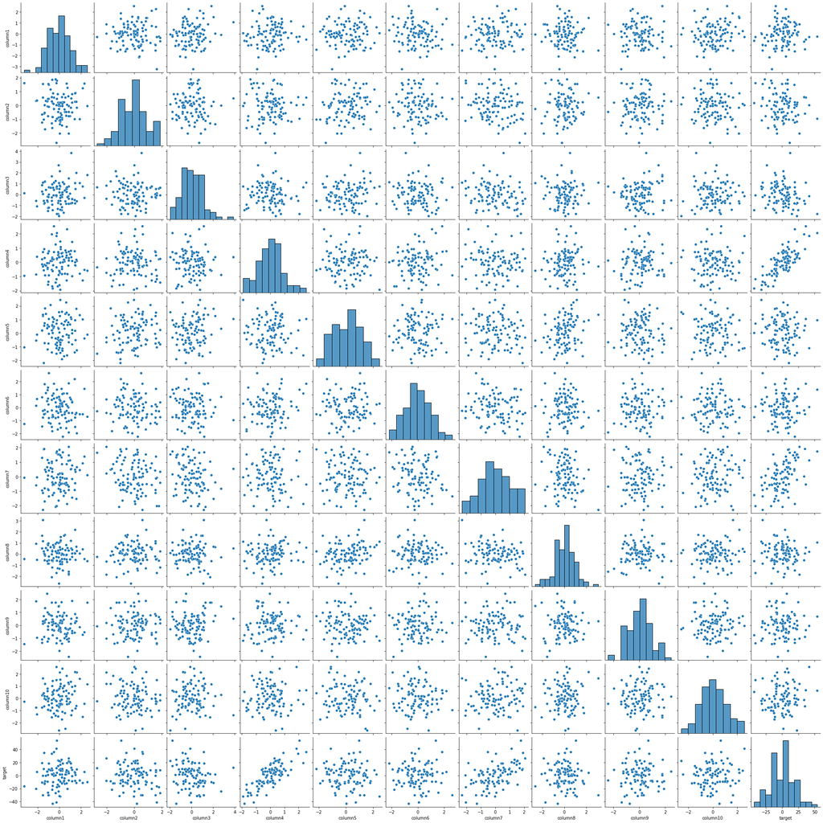

```python
import seaborn as sns

sns.pairplot(pd.concat([X,y], axis=1))
```

### 4.2.1. train_test_split

データを二つに分割してくれる(7:3でデータを分割など)

- train_test_split(説明変数, 目的変数, 分割の割合, random_state)

```python
from sklearn.model_selection import train_test_split

X_1, X_2, y_1, y_2 = train_test_split(X, y, test_size=0.3, random_state=42)
```

```python
# データが7:3になっているか確認
print("X_1のデータ数：", len(X_1))
print("X_2のデータ数：", len(X_2))
print("-----------------------")
print("y_1のデータ数：", len(y_1))
print("y_2のデータ数：", len(y_2))
```

```
X_1のデータ数： 70
X_2のデータ数： 30
-----------------------
y_1のデータ数： 70
y_2のデータ数： 30
```

### 4.2.2. 各種機械学習モデル

どの機械学習モデルも決まったメソッドを持つ(機械学習モデルの基底クラスを継承して作成されている)． そのため，どのモデルを使っても同じ感覚で機械学習モデルを作成できる．

#### よく使うメソッド

- fit(説明変数, 目的変数)
  - 引数で渡したデータからモデルを学習させる
- predict(説明変数)
  - 学習ずみのモデルを使用して，引数で与えられたデータの予測値を返す

```python
from sklearn.linear_model import LinearRegression

# モデルの宣言
lr = LinearRegression()

# X_1からy_1を予測するように学習する
lr.fit(X_1, y_1)

# X_2のデータの予測値を計算する
print(lr.predict(X_2).squeeze())
```

```
[-12.2751992    1.62689814  10.40607919 -11.70096173 -10.91568389
  10.51877513  11.87249895  33.23135281  11.72542079 -19.88590677
  17.41645753  -2.78695818  -8.38359988 -23.14462457   6.67227983
 -43.9174325   -4.68090685   2.71388519   1.76478142   3.13000815
 -11.76851762   9.78959057 -14.70037207 -28.16998388   9.18838101
 -28.78345145  36.66391344  15.35275359  -8.45742525 -11.52937283]
```

```python
# モデルを変えても，同じようにモデルの学習・予測が行える
from sklearn.ensemble import RandomForestRegressor

# モデルの宣言
rfr = RandomForestRegressor()

# X_1からy_1を予測するように学習する
rfr.fit(X_1, y_1)

# X_2のデータの予測値を計算する
print("予測値\n", rfr.predict(X_2).squeeze())
```

```
予測値
 [ -7.60567526   1.89741523   7.30453663 -11.54888474  -4.54232381
   4.96251745  11.32553084  17.46468063   9.39736592 -21.49901633
  13.97522184  -6.39519741 -13.16520478 -19.71607259   3.62422056
 -25.61680812  -4.28161576   5.85136614   2.65301222   3.30202526
  -7.10525749   7.88867408 -11.13692149 -25.33476162   6.83567967
 -23.11569532  12.807272    13.68355055  -9.70064868 -17.11202436]
```

### 4.2.3. 各種metric計算

作成したモデルがどの程度の性能なのかを図る指標(metric)を計算する．  
色々な種類があるので，その時々に応じて使い分ける．

大体は，metric(予測値, 真値)で計算してくれる．

例) MSE (Mean Squared Error)

$$ MSE(\hat{y}, y) = \frac{1}{m} \sum_{i=1}^m(\hat{y}^{(i)} - y^{(i)})^2 $$

```python
from sklearn.metrics import mean_squared_error

# 予測値を取得
y_hat = rfr.predict(X_2).squeeze()

# MSEの計算(小さい方が良い)
print("MSE score： ", mean_squared_error(y_hat, y_2))
```

```
MSE score：  50.03208680333383
```